# Worksheet 8 : Probability

## Today’s Agenda

- Probability
- Total Probability
- Fundamental Counting Principle

## Probability

- Probability is the language of likelihoods

### Random Variables

- A **random variable** is an object that depends on the outcome of a random event, usually denoted by $X$
- Examples of a random variable: the face showing for a dice roll, the number of $5$’s in $10$ die rolls, the number of children in a family, the amount of time before a light bulb goes out.
- there are discrete random variables and continuous random variables.
1. What is the sample space if two different integers are chosen between $1$ and $5$ and listed in increasing order?

answer here

2. What is the sample space if three dice are rolled and the sum is computed?

answer here

3. Choose $2$ marbles from a bag with $2$ red marbles, $2$ blue marbles, and $1$ green marble.

answer here

4. If roll two 4-sided dice, what is the probability of getting doubles?

Answer here

5. What is the probability of getting at least one head when flipping a coin twice?

Answer here

## Fundamental Counting Principle

## Probability Distribution

6. Is the following graph a probability distribution describing flipping two fair coins. Why or why not?

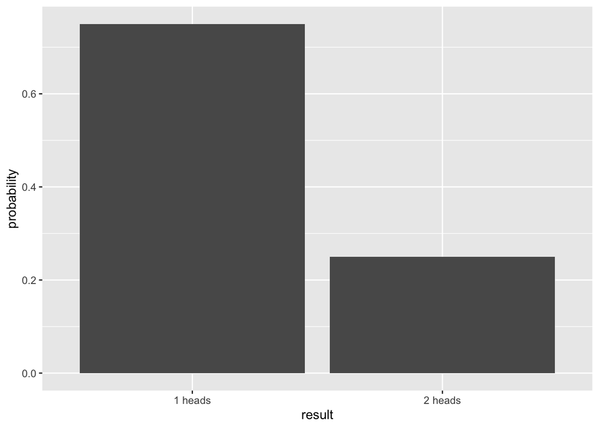

```r
coin <- data.frame(result = c("2 heads", "1 heads"), probability = c(1/4,3/4))
ggplot(coin, aes(x=result,y=probability))+geom_bar(stat="identity")
```

Answer here

7. What is the probability of pulling two red marbles from a bag with 2 red marbles, 2 blue marbles, and 1 green marble?

Answer here

8. On a six sided fair die, what is the probability of rolling an even number or a one?

Answer here

9. What is the probability of getting at least one heads if you flip a coin three times?

Answer here

10. From the very first question on this worksheet, what is the probability of the first number being a $2$? What is the probability of the first number being a $5$?

Answer here